## Homework Assignment 11

#### Due Friday, April 28, 2022, at 11:59 PM

### Preliminaries

- Directories
  - COURSE/homework/
  - COURSE/homework/hw11/
  - COURSE/data/
  - COURSE/scripts/
- Files
  - COURSE/homework/hw11/hw11.Rmd
  - COURSE/data/boston-marathon-data.csv
  - COURSE/data/dugong.csv
  - COURSE/scripts/viridis.R
  - COURSE/scripts/ggprob.R

### Data

- Some problems use the official Madison weather data, `madison-weather-official-1869-2022.csv`.
- Additional problems use the Boston Marathon data in the file `boston-marathon-data.csv`. This file is a transformed version of the raw data we used in class and has data for all runners who completed the race in 2010 and 2011. The variable `Time` is the sum of the times from the different portions of the race, each of which begins with “K”.

### Aims

- Practice regression

## Problems

**1.** In a regression problem to estimate $y$ from explanatory variable $x$ from a sample of size $n$, partial summary information is $\bar{x} = 20$ and $\bar{y} = 100$. Regardless of the values of other summary statistics, what is the value the predicted value $\hat{y}$ at a point where $x = 20$? Briefly explain.

```r
yhat = ((20*20)+100)
yhat
```

```
## [1] 500
```

> yhat equation is B0 + B1X1, we’re given 3 values. So muliplying and adding the equation, we get yhat equal to 500

**2.** In a regression problem to estimate $y$ from explanatory variable $x$ from a sample of size $n$, partial summary information is $\bar{x} = 20$, $s_x = 5$, $\bar{y} = 100$, and $s_y = 15$. Which of the following values are possible values for the predicted value $\hat{y}$ when the explanatory variable has value $x = 30$? Briefly explain.

```r
xbar=20
ybar = 100
sy=15
sx=5
r = cor(c(xbar, sx), c(ybar, sy))
b1 = r/(sy/sx)
b0 = ybar - (b1-xbar)
yhat2 = b0+b1*xbar
yhat2
```

```
## [1] 126.3333
```

**(a)** 50  
**(b)** 70  
**(c)** 100  
**(d)** 120  
**(e)** 150

> Answer is D. With our given values, we can calulate what b0 and b1 is, and we are given what x is. we multiply these three values to ge 126.3333, which is closest to answer D, which is 120.

Problems 3–6 are based on the data set in the file *dugong.csv* which relates age (in years) and length (in meters) of a sample of 27 dugongs, a type of marine mammal.

Credit: The *dugong.csv* file is from Data8 at UC-Berkeley.

**3.**

- Read in the *dugong.csv* data set.
- Create a scatter plot with `length` on the x-axis and `age` on the y-axis; be sure to add descriptive axis labels (include units of measurement) and a title.
- Using `geom_smooth()`, add the least-squares line to your plot.

```r
dugong = read_csv("../../data/dugong.csv")
```

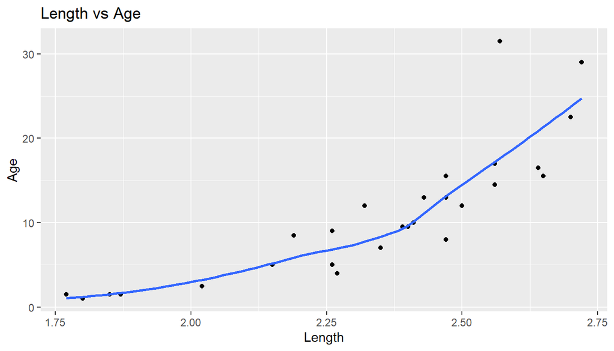

```r
ggplot(dugong, aes(x = Length, y = Age))+
  geom_point()+
  geom_smooth(se = FALSE)+
  xlab("Length")+
  ylab("Age")+
  ggtitle("Length vs Age")
```

**4.**

- Using the dugong data, calculate the sample means, sample standard deviations, and correlation coefficient of the variables `age` and `length`.
- Using formulas from lecture, calculate the slope and intercept of the least squares regressions line to predict age with length.

```r
samplemeanage= mean(dugong$Age)
samplemeanlength= mean(dugong$Length)
samplesdage = sd(dugong$Age)
samplesdlength= sd(dugong$Length)
corr = cor(dugong$Length, dugong$Age)

slope = corr*(samplesdage/samplesdlength)
intercept = samplemeanage - slope*samplemeanlength
slope
```

```
## [1] 23.77168
```

```r
intercept
```

```
## [1] -44.56683
```

- Use the dugong data and the functions `lm()` and `coef()` to calculate the slope and intercept of the least squares regression line of age against length (use length to predict age).

```r
df = tibble(x=dugong$Length, y = dugong$Age)
lm = lm(y~x, df)
summary(lm)
```

```
##
## Call:
## lm(formula = y ~ x, data = df)
##
## Residuals:
##    Min     1Q Median     3Q    Max
## -6.149 -2.805 -0.952  1.515 14.974
##
## Coefficients:
##             Estimate Std. Error t value Pr(>|t|)
## (Intercept)  -44.567      7.521  -5.926 3.48e-06 ***
## x             23.772      3.199   7.430 8.79e-08 ***
## ---
## Signif. codes:  0 '***' 0.001 '**' 0.01 '*' 0.05 '.' 0.1 ' ' 1
##
## Residual standard error: 4.48 on 25 degrees of freedom
## Multiple R-squared:  0.6883, Adjusted R-squared:  0.6758
## F-statistic: 55.21 on 1 and 25 DF,  p-value: 8.794e-08
```

```r
coef(lm)
```

```
## (Intercept)           x
##   -44.56683    23.77168
```

- Verify that you get the same values.

  **5.**
- Add columns with the predicted values and residuals to the dugong data set. *(You can use* **modelr** *functions or just use `mutate()` and calculate these values directly.)*
- Plot the residuals versus length.
  - Add a horizontal line at $y=0$ and appropriate labels on each axis.

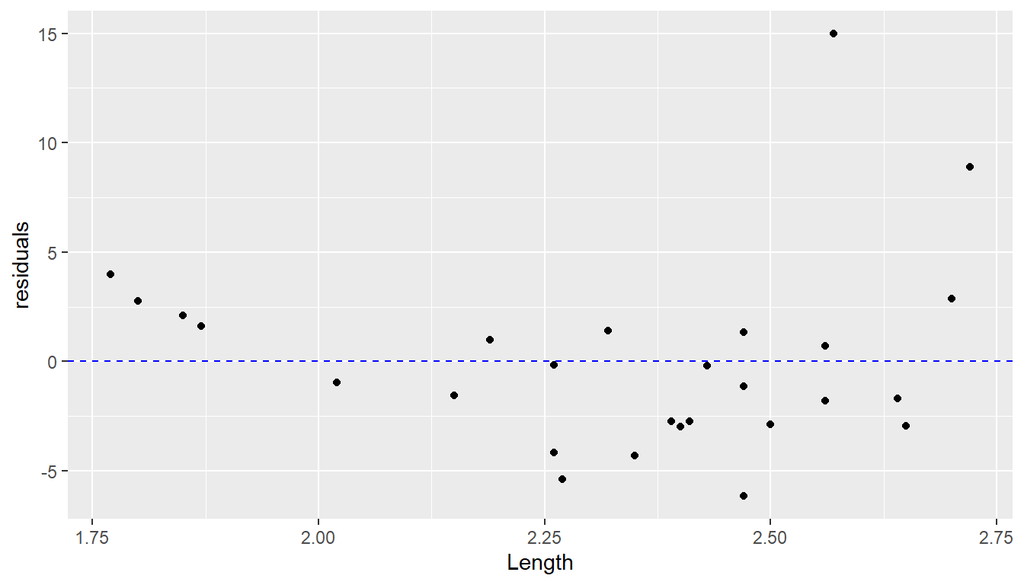

```r
df2 = df %>%
  add_residuals(lm) %>%
  add_predictions(lm)

ggplot(df2, aes(x =x ,y = resid ))+
  geom_point()+
  geom_hline(yintercept=0, linetype = "dashed", color = "blue")+
  xlab("Length")+ylab("residuals")
```

- Describe what the residual plot suggests about the appropriateness of using simple linear regression to predict age from length of dugongs.

> the residual plot appears to be quadratic, as it starts positve, goes negative, then positive again. This means that average longer dugongs tend to have a lower age, compared to longer dugongs and shorter dugongs.

**6.**

- Print the summary of the fitted regression model

```r
summary(df2)
```

```
##        x               y             resid             pred
##  Min.   :1.770   Min.   : 1.00   Min.   :-6.149   Min.   :-2.491
##  1st Qu.:2.225   1st Qu.: 5.00   1st Qu.:-2.805   1st Qu.: 8.325
##  Median :2.400   Median : 9.50   Median :-0.952   Median :12.485
##  Mean   :2.335   Mean   :10.94   Mean   : 0.000   Mean   :10.944
##  3rd Qu.:2.530   3rd Qu.:15.00   3rd Qu.: 1.515   3rd Qu.:15.576
##  Max.   :2.720   Max.   :31.50   Max.   :14.974   Max.   :20.092
```

```r
summary(lm)
```

```
##
## Call:
## lm(formula = y ~ x, data = df)
##
## Residuals:
##    Min     1Q Median     3Q    Max
## -6.149 -2.805 -0.952  1.515 14.974
##
## Coefficients:
##             Estimate Std. Error t value Pr(>|t|)
## (Intercept)  -44.567      7.521  -5.926 3.48e-06 ***
## x             23.772      3.199   7.430 8.79e-08 ***
## ---
## Signif. codes:  0 '***' 0.001 '**' 0.01 '*' 0.05 '.' 0.1 ' ' 1
##
## Residual standard error: 4.48 on 25 degrees of freedom
## Multiple R-squared:  0.6883, Adjusted R-squared:  0.6758
## F-statistic: 55.21 on 1 and 25 DF,  p-value: 8.794e-08
```

- The simple linear regression model for $Y_i$ conditional on the values of $X_i = x_i$ is

$$\mathsf{E}(Y_i \mid X_i = x_i) = \beta_0 + \beta_1 x_i + \varepsilon_i,
\quad \text{for $i = 1, \ldots,n$}$$

where $\varepsilon_i \sim \text{Normal}(0, \sigma)$ for some parameter $\sigma > 0$.

- The parameter $\sigma$ is the unknown population standard deviation of the typical distance between a point $Y_i$ and its true expected value.
- Use the function `sigma()` on the fitted regression object (what you created with `lm()`) to extract the estimate of $\sigma$. Identify where this numerical value appears in the printed summary you made earlier.

```r
sigma(lm)
```

```
## [1] 4.480469
```

$$\sqrt{ \frac{\sum_{i=1}^n (y_i - \hat{y}_i)^2}{n-2} }$$

where the $i$th residual is $y_i - \hat{y}_i$.

```r
meanresid = mean(df2$resid)
n = nrow(df2)
y= 23.77168*sigma(lm) -44.56683
yhat = mean(df2$y)+cor(df2$x, df2$y)*(23.77168-mean(df2$x))/sd(df2$x)
sigma = ((y-yhat)*(y-yhat))/(n-2)
sqrt(sigma)
```

```
## [1] 2.751351
```

- Problems 7–8 use the cleaned Boston Marathon data in `boston-marathon-data.csv`.

  **7.**
- Read in the Boston marathon data fro the file `boston-marathon-data.csv`.

```r
marathon = read_csv("../../data/boston-marathon-data.csv")
```

- Create a scatter plots of `Time` versus `Age` for the female runners in 2010.
  - Add a straight regression line
  - Add a smooth curve
- As there are so many points, you may set `alpha` to a value less than one inside of `geom_point()` to lessen the effects of overplotting.

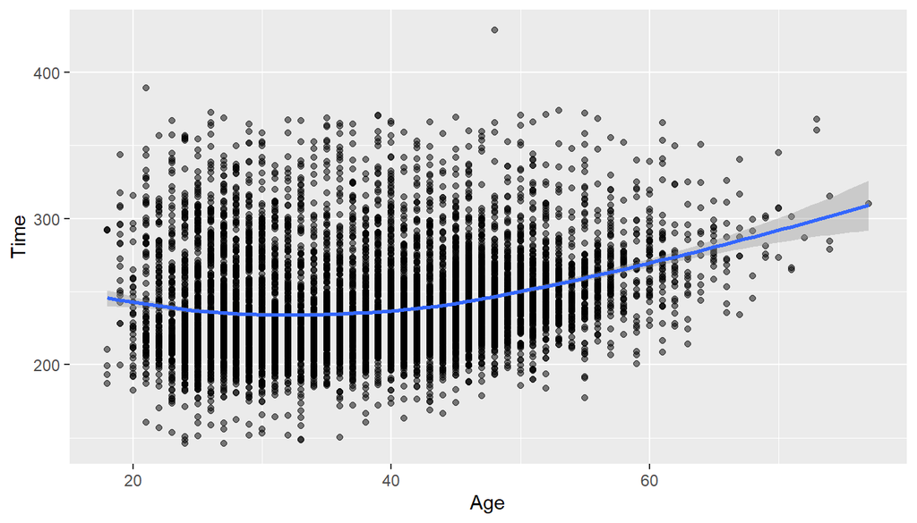

```r
women = marathon %>%
  filter(Year == 2010,
         Sex == "female")

ggplot(women, aes(x = Age, y = Time))+
  geom_point(alpha = 0.5)+
  geom_smooth()
```

- Make a residual plot of the residuals versus `Age`.
  - Include a horizontal line at $y=0$
  - Include a smooth curve through the residuals
- In addition, make a density plot of the residuals.

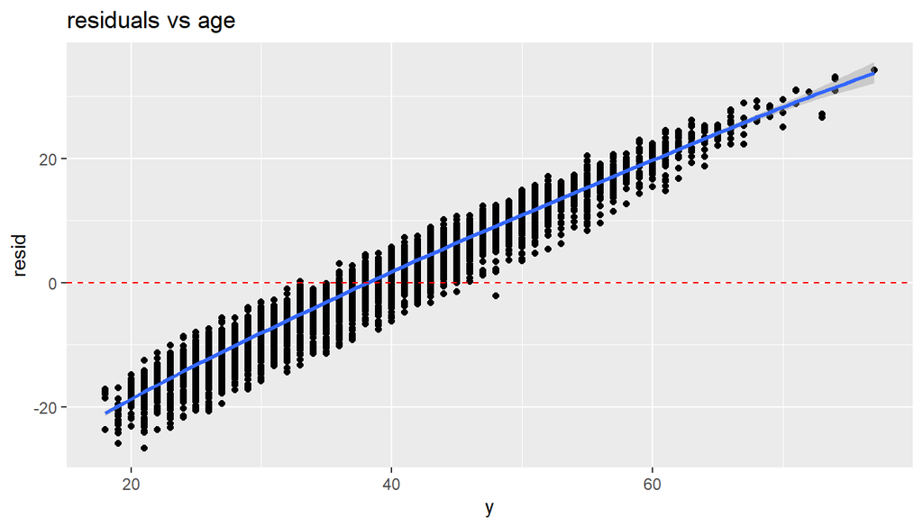

```r
ggplot(df4, aes(x = y, y = resid))+
  geom_point()+
  geom_smooth()+
  geom_hline(yintercept = 0, linetype = "dashed", color ="red")+
  ggtitle("residuals vs age")
```

[output not shown]

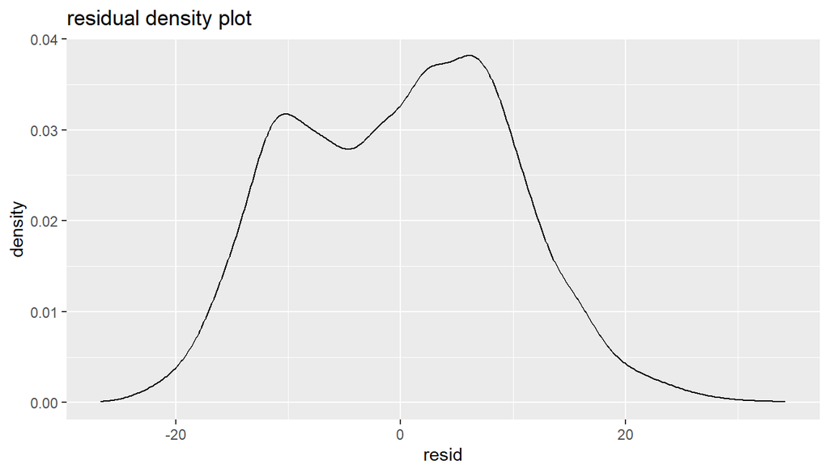

```r
ggplot(df4, aes(x = resid))+
  geom_density()+
  ggtitle("residual density plot")
```

**8.** Examine the residual plots from the previous problem.

- Is there evidence of strong non-linearity?

> Yes, looking at the distribution graph we plotted, the shape is not symmetrical, proving this. The scatter plot too shows that it is not symmetrical.